# Mueller_Thibeaux_Case Study

Thibeaux

2023-02-20

Introduction: Welcome to Nicholas Mueller’s and Alex Thibeaux’s case study. Through our code you will visually see insights on the distribution of beers and breweries among every state, along with interesting findings of different styled beers, IBUs, ABVs, and more. We have also provided alternative options to missing data so that we are able to get the full potential out of our data set. If you have any question feel free to reach out.

```r
library(maps)
library(ggplot2)
library(ggthemes)
library(dplyr)
library(stringr)
library(class)
library(caret)
library(mice)
library(RColorBrewer)
library(tidyr)
```

These libraries will help us plot and manipulate our data so that we can visually present appropriate findings.

```r
beers <- read.csv('https://github.com/athibeaux/MSDS-DDS/raw/main/Mueller%20Thibeaux%20Case%20Study/Beers.csv', header = TRUE, fill = TRUE)
breweries <- read.csv('https://github.com/athibeaux/MSDS-DDS/raw/main/Mueller%20Thibeaux%20Case%20Study/Breweries.csv', header = TRUE, fill = TRUE)

merged <- merge(beers, breweries, by.x = "Brewery_id", by.y = "Brew_ID")
```

We took the beers and breweries data set and merged it into one data set so that we can use the entirety of the data to provide findings.

1. How many breweries are present in each state?

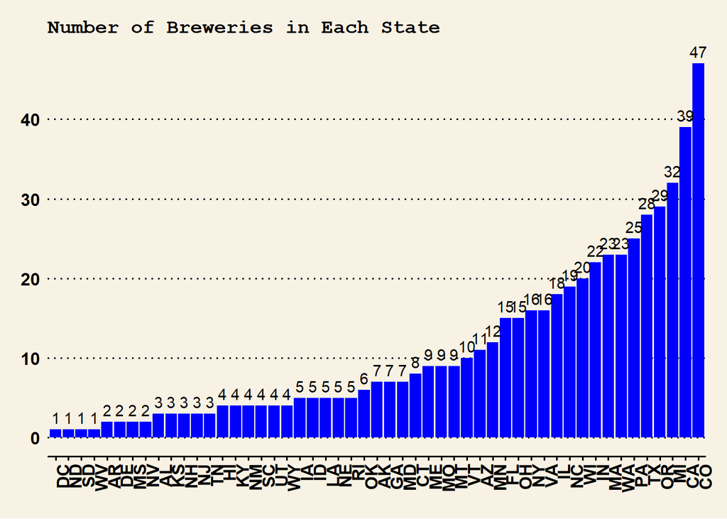

```r
breweries_by_state <- breweries %>%
  group_by(State) %>%
  summarize(Count = n())%>%
  arrange(desc(Count))

ggplot(breweries_by_state, aes(x = reorder(State, Count), y = Count)) +
  geom_bar(stat = "identity", fill = "blue") +
  xlab("State") + ylab("Number of Breweries") +
  ggtitle("Number of Breweries in Each State") +
  theme_wsj() + theme(plot.title = element_text(size = 14, face = "bold"),
                      axis.text.x = element_text(angle = 90, hjust = 1))+
  geom_text(aes(label = Count), vjust = -0.5)
```

2. Merge beer data with the breweries data. Print the first 6 observations and the last six observations to check the merged file. (RMD only, this does not need to be included in the presentation or the deck.)

```r
head(merged, 6)
```

```
##   Brewery_id        Name.x Beer_ID   ABV IBU
## 1          1  Get Together    2692 0.045  50
## 2          1 Maggie's Leap    2691 0.049  26
## 3          1    Wall's End    2690 0.048  19
## 4          1       Pumpion    2689 0.060  38
## 5          1    Stronghold    2688 0.060  25
## 6          1   Parapet ESB    2687 0.056  47
##                                 Style Ounces             Name.y        City
## 1                        American IPA     16 NorthGate Brewing  Minneapolis
## 2                  Milk / Sweet Stout     16 NorthGate Brewing  Minneapolis
## 3                   English Brown Ale     16 NorthGate Brewing  Minneapolis
## 4                         Pumpkin Ale     16 NorthGate Brewing  Minneapolis
## 5                     American Porter     16 NorthGate Brewing  Minneapolis
## 6 Extra Special / Strong Bitter (ESB)     16 NorthGate Brewing  Minneapolis
##   State
## 1    MN
## 2    MN
## 3    MN
## 4    MN
## 5    MN
## 6    MN
```

```r
tail(merged, 6)
```

```
##      Brewery_id                    Name.x Beer_ID   ABV IBU
## 2405        556             Pilsner Ukiah      98 0.055  NA
## 2406        557  Heinnieweisse Weissebier      52 0.049  NA
## 2407        557           Snapperhead IPA      51 0.068  NA
## 2408        557         Moo Thunder Stout      50 0.049  NA
## 2409        557         Porkslap Pale Ale      49 0.043  NA
## 2410        558 Urban Wilderness Pale Ale      30 0.049  NA
##                        Style Ounces                        Name.y          City
## 2405         German Pilsener     12         Ukiah Brewing Company         Ukiah
## 2406              Hefeweizen     12       Butternuts Beer and Ale Garrattsville
## 2407            American IPA     12       Butternuts Beer and Ale Garrattsville
## 2408      Milk / Sweet Stout     12       Butternuts Beer and Ale Garrattsville
## 2409 American Pale Ale (APA)     12       Butternuts Beer and Ale Garrattsville
## 2410        English Pale Ale     12 Sleeping Lady Brewing Company     Anchorage
##      State
## 2405    CA
## 2406    NY
## 2407    NY
## 2408    NY
## 2409    NY
## 2410    AK
```

We are able to see the top 6 and last 6 values in each column.

3. Address the missing values in each column.

```r
# Load the mice package
library(mice)

# Convert IBU variable to factor
merged$IBU <- as.factor(merged$IBU)

# Create a mice imputation object with predictive mean matching
imp <- mice(merged, method = "pmm")
# Generate 5 imputed datasets
imputed_data <- complete(imp, 5)

# Combine the imputed datasets into a single data frame
combined_data <- complete(imp, action = "long")

# Use the complete data for subsequent analysis
imputed_beers <- combined_data[combined_data$".imp" == 5, ]

Imputed_IBU=imputed_beers$IBU

merged_Imputed <- cbind(merged, Imputed_IBU)
```

We used a library function call multivariate imputation via chained equation or mice for short. This is a type of regression model which uses a predictive mean matching technique that uses values like style, ABV, and other columns in the data set to predict missing values like IBU.

4. Compute the median alcohol content and international bitterness unit for each state. Plot a bar chart to compare.

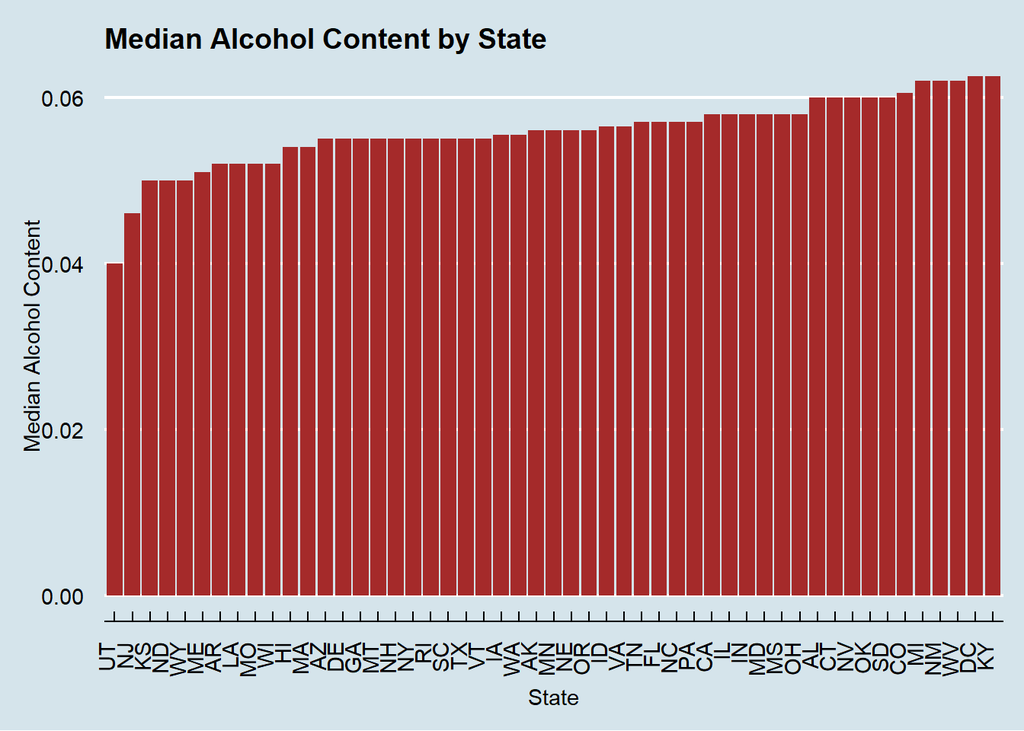

```r
# Since our imputation of the data converted the continues variables into factors, we will now change them back to numeric in order to run statistical analysis on them.
merged_Imputed$IBU=as.numeric(merged_Imputed$IBU)
merged_Imputed$ABV=as.numeric(merged_Imputed$ABV)
merged_Imputed$Imputed_IBU=as.numeric(merged_Imputed$Imputed_IBU)

# Create a new dataframe that has the Median ABV and IBU by state
merged3<- merged_Imputed %>%
  group_by(State) %>%
  summarize(median_abv = median(ABV, na.rm = TRUE),
            median_ibu = median(IBU, na.rm = TRUE),
            median_imputedIBU= median(Imputed_IBU, na.rm=TRUE))


# Bar Chart of Median ABV by State
ggplot(merged3, aes(x = reorder(State, median_abv), y = median_abv)) +
  geom_bar(stat = "identity", fill = "brown") +
  xlab("State") + ylab("Median Alcohol Content") +
  ggtitle("Median Alcohol Content by State") +
  theme_economist() + theme(plot.title = element_text(size = 14, face = "bold"),
                     axis.text.x = element_text(angle = 90, hjust = 1))
```

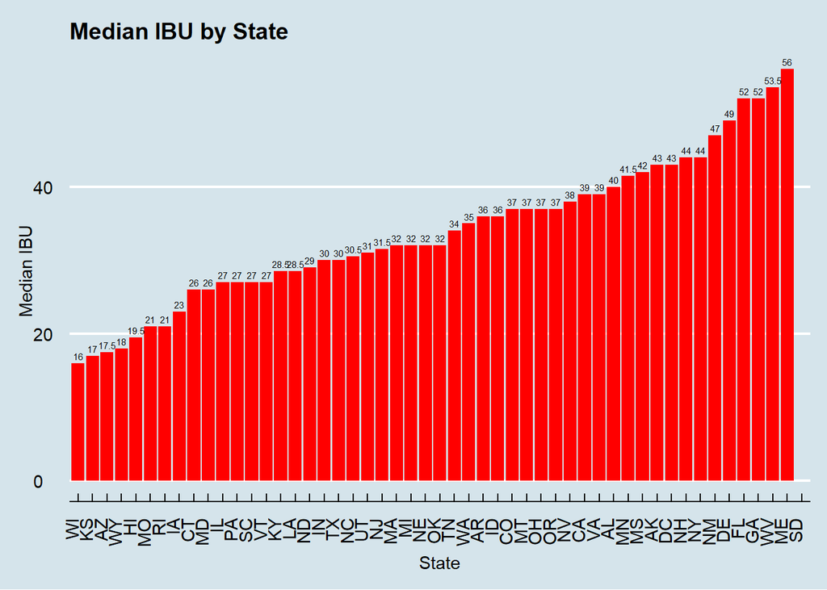

```r
# Bar Chart of Median IBU by State (raw data)
ggplot(merged3, aes(x = reorder(State,  median_ibu), y =  median_ibu)) +
  geom_bar(stat = "identity", fill = "red") +
  xlab("State") + ylab("Median IBU") +
  ggtitle("Median IBU by State") +
  theme_economist() +
  geom_text(aes(label = median_ibu), position = position_nudge(y = 1), size = 2) +
  theme(plot.title = element_text(size = 14, face = "bold"),
                     axis.text.x = element_text(angle = 90, hjust = 1))
```

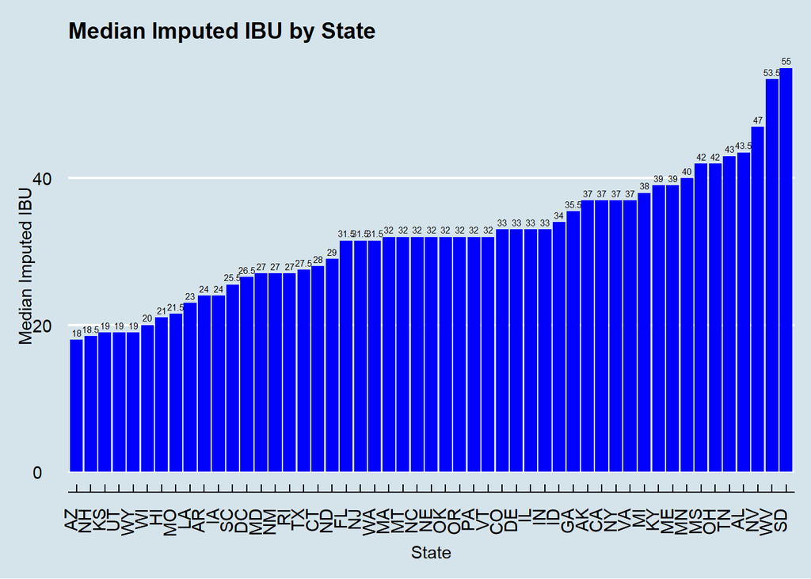

```r
# Bar Chart of Median IBU by State (imputed data)
ggplot(merged3, aes(x = reorder(State,  median_imputedIBU), y =  median_imputedIBU)) +
  geom_bar(stat = "identity", fill = "blue") +
  xlab("State") + ylab("Median Imputed IBU") +
  ggtitle("Median Imputed IBU by State") +
  theme_economist() + geom_text(aes(label = median_imputedIBU), position = position_nudge(y = 1), size = 2) +
  theme(plot.title = element_text(size = 14, face = "bold"),
        axis.text.x = element_text(angle = 90, hjust = 1))
```

For question 4 we used the merged data set with the imputed IBU column and the original IBU column to plot a bar chart of median IBU per state along with a bar chart of median ABV per state.

5. Which state has the maximum alcoholic (ABV) beer? Which state has the most bitter (IBU) beer?

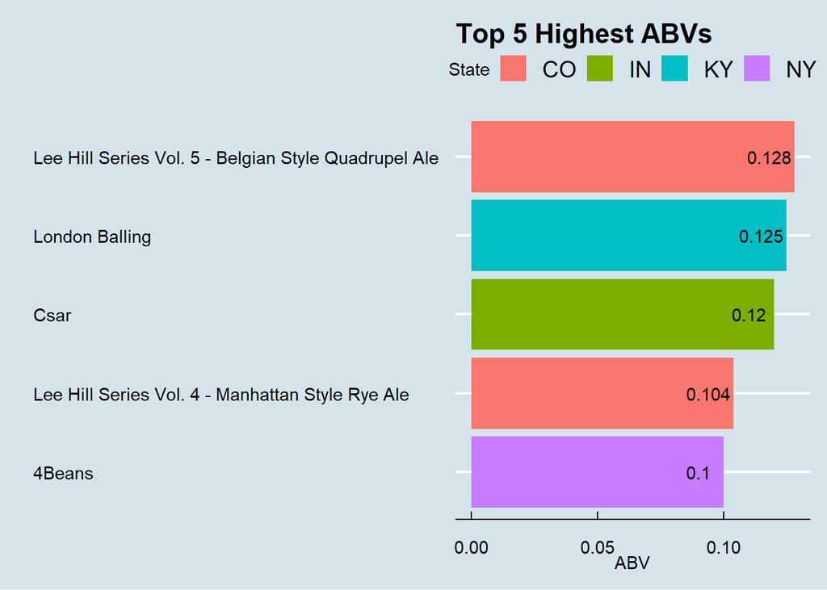

```r
# Bar chart of Top 5 Highest ABVs
merged_Imputed %>%
  group_by(State,Name.x) %>%
  arrange(desc(ABV))%>%
  head(5)%>%
  ggplot(aes(x=reorder(Name.x,ABV),y=ABV, fill=State)) +
  xlab("") + geom_col() + coord_flip() + theme_economist() +
  ggtitle("Top 5 Highest ABVs") +
  geom_text(aes(label = ABV), position = position_nudge(y = -.01))
```

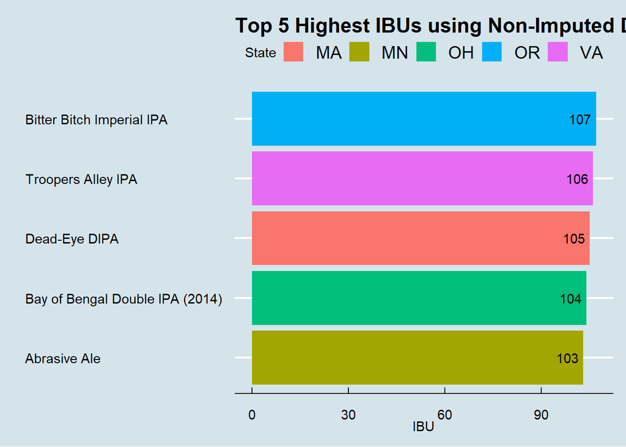

```r
# Bar chart of Top 5 Highest IBUs (Non-Imputed Data)
merged_Imputed %>%
  group_by(State,Name.x) %>%
  arrange(desc(IBU))%>%
  head(5)%>%
  ggplot(aes(x=reorder(Name.x,IBU),y=IBU, fill=State)) +
  xlab("") + ylab("IBU") +
  ggtitle("Top 5 Highest IBUs using Non-Imputed Data") +
  geom_col() + coord_flip() + theme_economist() +
  geom_text(aes(label = IBU), position = position_nudge(y = -5))
```

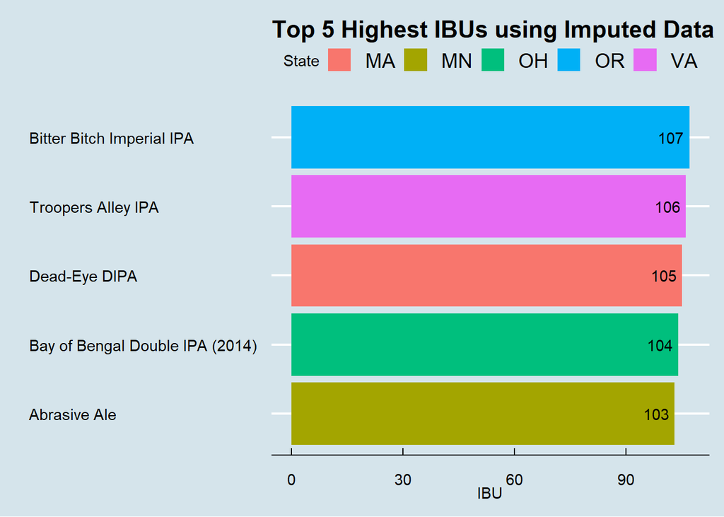

```r
# Bar chart of Top 5 Highest IBUs (Imputed Data)
merged_Imputed %>%
  group_by(State,Name.x) %>%
  arrange(desc(IBU))%>%
  head(5)%>%
  ggplot(aes(x=reorder(Name.x,Imputed_IBU),y=Imputed_IBU, fill=State)) +
  xlab("") + ylab("IBU") + ggtitle("Top 5 Highest IBUs using Imputed Data") +
  geom_col() + coord_flip() + theme_economist() +
  geom_text(aes(label = Imputed_IBU), position = position_nudge(y = -5))
```

6. Comment on the summary statistics and distribution of the ABV variable.

```r
# View Summary Statistics and Mean
summary(merged$ABV)
```

```
##    Min. 1st Qu.  Median    Mean 3rd Qu.    Max.    NA's
## 0.00100 0.05000 0.05600 0.05977 0.06700 0.12800      62
```

```r
mean(!is.na(merged$ABV))
```

```
## [1] 0.9742739
```

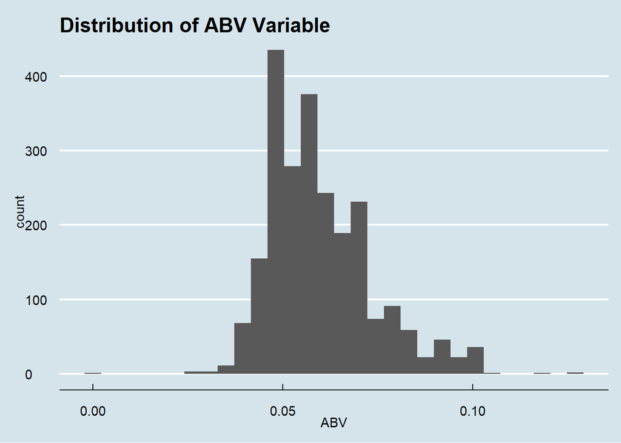

```r
# Create Histogram and Boxplot
merged %>% ggplot() + geom_histogram(aes(x = ABV)) +
  theme_economist() + ggtitle("Distribution of ABV Variable")
```

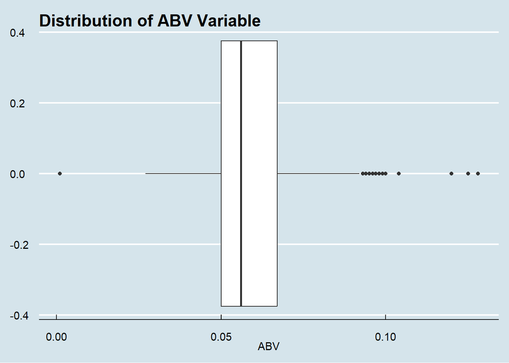

```r
merged %>% ggplot() + geom_boxplot(aes(x = ABV)) + theme_economist() + ggtitle("Distribution of ABV Variable")
```

For question 6 we used a summary tool in Rstudio to be able to determine the ABV minimum, average, and maximum content among the 50 states. Once retrieving the statistics we decided to plot a histogram and box plot to visually display the findings using ggplot.

7. Is there an apparent relationship between the bitterness of the beer and its alcoholic content? Draw a scatter plot. Make your best judgment of a relationship and EXPLAIN your answer.

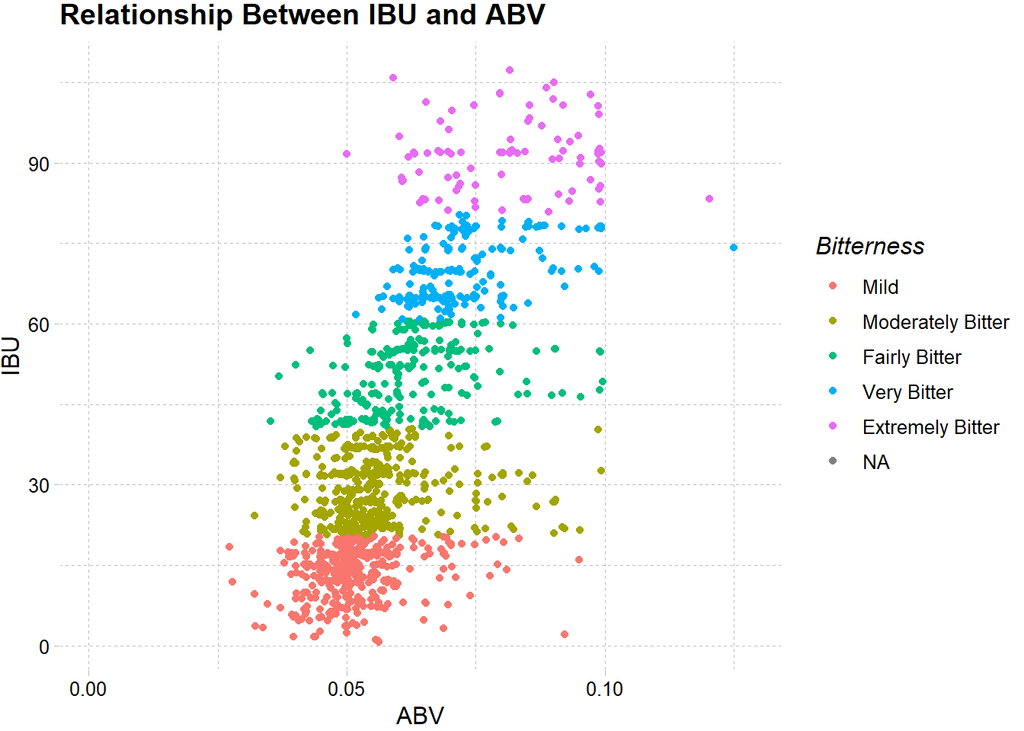

```r
#Labeled the breaks in IBU from mild to extremely bitter
merged_Imputed$Bitterness <- cut(as.numeric(merged$IBU), breaks=c(0, 20, 40, 60, 80, 140), labels=c('Mild', 'Moderately Bitter', 'Fairly Bitter', 'Very Bitter', 'Extremely Bitter'))

# Non-imputed Data
merged_Imputed %>% ggplot() + geom_jitter(aes(x = ABV, y = IBU, color=Bitterness))+ggtitle("Relationship Between IBU and ABV") + theme_pander()
```

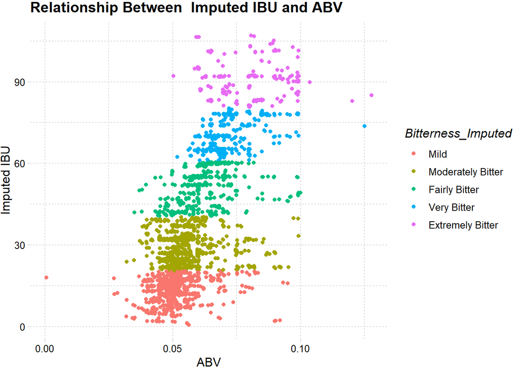

```r
#Labeled the breaks in Imputed IBU from mild to extremely bitter
merged_Imputed$Bitterness_Imputed <- cut(as.numeric(merged_Imputed$Imputed_IBU), breaks=c(0, 20, 40, 60, 80, 140), labels=c('Mild', 'Moderately Bitter', 'Fairly Bitter', 'Very Bitter', 'Extremely Bitter'))

# Imputed Data
merged_Imputed %>% ggplot() + geom_jitter(aes(x = ABV, y = Imputed_IBU, color=Bitterness_Imputed))+ylab("Imputed IBU")+ggtitle("Relationship Between  Imputed IBU and ABV")+ theme_pander()
```

For question 7 we used the scatter plot method in R studio to show the relationship between IBU and ABV. We displayed one scatter plot with the original data and the other scatter plot with the imputed IBU.

8. Budweiser would also like to investigate the difference with respect to IBU and ABV between IPAs (India Pale Ales) and other types of Ale (any beer with “Ale” in its name other than IPA). You decide to use KNN classification to investigate this relationship. Provide statistical evidence one way or the other. You can of course assume your audience is comfortable with percentages … KNN is very easy to understand conceptually.

```r
# Find IPA and Ale Rows
sum(str_count(merged$Style,"IPA"))
```

```
## [1] 571
```

```r
sum(str_count(merged$Style,"Ale"))
```

```
## [1] 976
```

```r
merged$IPA <- as.factor(ifelse(grepl("IPA", merged$Style), TRUE, FALSE))
merged$Ale <- as.factor(ifelse(grepl("Ale", merged$Style) & merged$IPA == FALSE, TRUE, FALSE))

summary(merged)
```

```
##    Brewery_id       Name.x             Beer_ID            ABV
##  Min.   :  1.0   Length:2410        Min.   :   1.0   Min.   :0.00100
##  1st Qu.: 94.0   Class :character   1st Qu.: 808.2   1st Qu.:0.05000
##  Median :206.0   Mode  :character   Median :1453.5   Median :0.05600
##  Mean   :232.7                      Mean   :1431.1   Mean   :0.05977
##  3rd Qu.:367.0                      3rd Qu.:2075.8   3rd Qu.:0.06700
##  Max.   :558.0                      Max.   :2692.0   Max.   :0.12800
##                                                      NA's   :62
##       IBU          Style               Ounces         Name.y
##  20     :  82   Length:2410        Min.   : 8.40   Length:2410
##  35     :  60   Class :character   1st Qu.:12.00   Class :character
##  65     :  54   Mode  :character   Median :12.00   Mode  :character
##  30     :  53                      Mean   :13.59
##  70     :  48                      3rd Qu.:16.00
##  (Other):1108                      Max.   :32.00
##  NA's   :1005
##      City              State              IPA          Ale
##  Length:2410        Length:2410        FALSE:1839   FALSE:1447
##  Class :character   Class :character   TRUE : 571   TRUE : 963
##  Mode  :character   Mode  :character
##
##
##
##
```

```r
alesNA <- filter(merged, merged$IPA == TRUE | merged$Ale == TRUE)
ales <- alesNA[complete.cases(alesNA),]
ales$AleOrIPA <- as.factor(ifelse(ales$Ale == TRUE, "Ale", "IPA"))
summary(ales)
```

```
##    Brewery_id        Name.x             Beer_ID            ABV
##  Min.   :  1.00   Length:944         Min.   :   1.0   Min.   :0.03500
##  1st Qu.: 99.75   Class :character   1st Qu.: 786.8   1st Qu.:0.05200
##  Median :202.00   Mode  :character   Median :1457.5   Median :0.06000
##  Mean   :226.40                      Mean   :1418.1   Mean   :0.06178
##  3rd Qu.:345.25                      3rd Qu.:2068.2   3rd Qu.:0.07000
##  Max.   :547.00                      Max.   :2692.0   Max.   :0.09900
##
##       IBU         Style               Ounces         Name.y
##  20     : 54   Length:944         Min.   :12.00   Length:944
##  65     : 51   Class :character   1st Qu.:12.00   Class :character
##  70     : 48   Mode  :character   Median :12.00   Mode  :character
##  35     : 41                      Mean   :13.51
##  60     : 41                      3rd Qu.:16.00
##  30     : 32                      Max.   :32.00
##  (Other):677
##      City              State              IPA         Ale      AleOrIPA
##  Length:944         Length:944         FALSE:552   FALSE:392   Ale:552
##  Class :character   Class :character   TRUE :392   TRUE :552   IPA:392
##  Mode  :character   Mode  :character
##
##
##
##
```

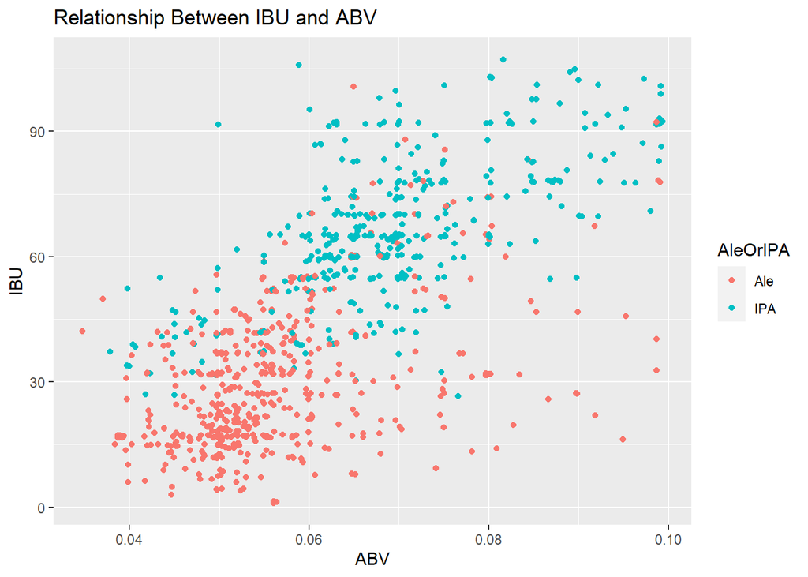

```r
# Display Scatterplot of dataset with only IPAs and Ales
ales %>% ggplot() + geom_jitter(aes(x = as.numeric(ABV), y = as.numeric(IBU), color=AleOrIPA))+xlab("ABV") + ylab("IBU")+ggtitle("Relationship Between IBU and ABV")
```

We were able to filter the IPA and ale from the original data set making sure that if the style had both IPA and Ale in the name it would be classified as IPA.

KNN Model

```r
# KNN
iterations = 100
splitPerc = .70

masterAcc = matrix(nrow = iterations)

for(j in 1:iterations)
{
accs = data.frame(accuracy = numeric(90), k = numeric(90))
trainIndices = sample(1:dim(ales)[1],round(splitPerc * dim(ales)[1]))
train = ales[trainIndices,]
test = ales[-trainIndices,]
classifications = knn(train[,c(4,5)],test[,c(4,5)],train$AleOrIPA, prob = TRUE, k = 30)
  table(classifications,test$AleOrIPA)
  CMknn = confusionMatrix(table(classifications,test$AleOrIPA))
  masterAcc[j] = CMknn$overall[1]
}

MeanAcc = colMeans(masterAcc)
MeanAcc
```

```
## [1] 0.8427562
```

```r
CMknn$byClass[1]
```

```
## Sensitivity
##   0.8855422
```

```r
CMknn$byClass[2]
```

```
## Specificity
##   0.7948718
```

We used the k-nearest-neighbor model to show that we are able to predict wehter a beer is an IPA or an Ale based on the IBU and ABV statistics or numbers for that beer. The KNN model looks at the scatter plot of the relationship between IBU and ABV and selects the nearest neighbors (K being how many nearest neighbors you want) and depending on what the majority nearest to the point being evaluated will be the predicted category. We used K=30 because of how large the data set is.

The KNN uses a train and a test set to estimate how accurate the model will be. Since we have the correct categories in the test set we are able to see how accurate the predication model is at predication whether the beer is Ale or IPA. The KNN model will run different train and tests sets every time, however majority of the time the accuracy lies between 80% and 90%, sensitivity between 80% and 90%, and specificity between 75% and 85%.

In addition, while you have decided to use KNN to investigate this relationship (KNN is required) you may also feel free to supplement your response to this question with any other methods or techniques you have learned. Creativity and alternative solutions are always encouraged.

9. Knock their socks off! Find one other useful inference from the data that you feel Budweiser may be able to find value in. You must convince them why it is important and back up your conviction with appropriate statistical evidence.

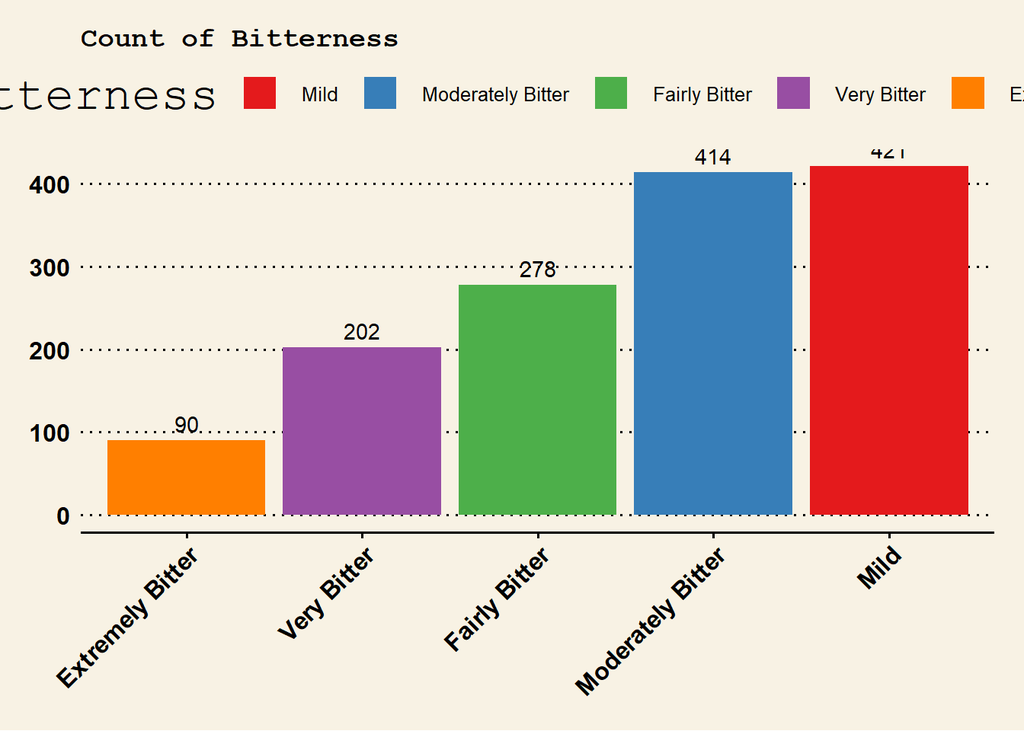

```r
library(tidyr)

#Labeled the breaks in IBU from mild to extremely bitter
merged_Imputed$Bitterness <- cut(as.numeric(merged$IBU), breaks=c(0, 20, 40, 60, 80, 140), labels=c('Mild', 'Moderately Bitter', 'Fairly Bitter', 'Very Bitter', 'Extremely Bitter'))

bitterness_count <- merged_Imputed %>%
  drop_na(Bitterness) %>%
  group_by(Bitterness) %>%
  summarize(Count = n()) %>%
  arrange(desc(Count))


# define colors for each bitterness value
colors <- brewer.pal(length(unique(bitterness_count$Bitterness)), "Set1")

#plot a bar graph to show the count of each level of bitterness
ggplot(bitterness_count, aes(x = reorder(Bitterness, Count), y = Count, fill = Bitterness)) +
  geom_bar(stat = "identity") +
  xlab("Bitterness") + ylab("Count") +
  ggtitle("Count of Bitterness") +
  theme_wsj() +
  theme(plot.title = element_text(size = 14, face = "bold"),
        axis.text.x = element_text(angle = 45, hjust = 1)) +
  geom_text(aes(label = Count), vjust = -0.5) +
  scale_fill_manual(values = setNames(colors, unique(bitterness_count$Bitterness)))
```

For question 9 we used the bitterness levels from mild to extremely bitter and displayed the count of each level with the given data.

We also used ChatGPT to form each level of bitterness and ranked them accordingly.

According to ChatGPT:

0-20 IBUs: Mild, low bitterness beers such as Scottish ales, brown ales, and cream ales. 20-40 IBUs: Moderately bitter beers such as English bitters, American amber ales, and most lagers. 40-60 IBUs: Fairly bitter beers such as IPAs, American pale ales, and most Belgian ales. 60-80 IBUs: Very bitter beers such as double IPAs, imperial stouts, and some barleywines. 80+ IBUs: Extremely bitter beers such as triple IPAs and some imperial stouts.

Why you should care! Since we did not have any sales data, that could be the next exploratory data analysis. Now that we know where the market is saturated we can take a look at the potential for exploring new markets that might be untapped by Budweiser. As we review the bar chart of the different levels we can see majority of beers are moderately bitter to mild(59% of beers), however only 6% of beers are extremely bitter. Therefore, we could find a lot of value exploring extremely bitter beers.

Conclusion: In the end we were able to retrieve all sorts of information. We were able to visually display the number of breweries per state, how each states differed in IBU and ABV, and what the average values of IBU and ABV were in each states. We also proceeded to displayed how IBU and ABV correlated with each other and how when the score of IBU increased so did the ABV.Then to round everything off we used the KNN model and MICE model to predict missing values and find the accuracy, specificity, and sensitivity among the data we were given.

Thank you for your time, we enjoyed working with this data and look forward to where our partnership will go.